# 19100085_MuhammadAbdullah_Nasim_assignment3_q1_q2

```python
import seaborn as sns
import numpy as np
import pandas as pd
import matplotlib.pyplot as plt
from matplotlib import pyplot as plt
from scipy import stats
from scipy.cluster.vq import kmeans
from sklearn.neighbors import LocalOutlierFactor
from sklearn.cluster import DBSCAN
from matplotlib import cm
from sklearn.cluster import KMeans
from sklearn.preprocessing import StandardScaler
from sklearn.cluster import AgglomerativeClustering
import scipy.cluster.hierarchy as sch
print('Libraries imported.')
```

```
Libraries imported.
```

## Q1) K-Means Clustering

K-means clustering is a method which aims to partition n observations into k clusters in which each observation belongs to the cluster with the nearest mean, serving as a prototype of the cluster.

In this question you will use K-Means clustering for 2 different examples

1. Implementing *k*-means clustering on a randomly generated dataset from scratch.
2. Implementing *k*-means using the SK-Learn library for cluster segmentation and profile building.

### 1. *k*-means on a Randomly Generated Dataset

30 data points belonging to 2 different clusters have been assigned  
x1 is the first feature and x2 the second

```python
x1 = [-4.9, -3.5, 0, -4.5, -3, -1, -1.2, -4.5, -1.5, -4.5, -1, -2, -2.5, -2, -1.5, 4, 1.8, 2, 2.5, 3, 4, 2.25, 1, 0, 1, 2.5, 5, 2.8, 2, 2]
x2 = [-3.5, -4, -3.5, -3, -2.9, -3, -2.6, -2.1, 0, -0.5, -0.8, -0.8, -1.5, -1.75, -1.75, 0, 0.8, 0.9, 1, 1, 1, 1.75, 2, 2.5, 2.5, 2.5, 2.5, 3, 6, 6.5]
```

```python
centers = [[-2, 2], [2, -2]]
colors_map = np.array(['b', 'r'])
# print(centers[0][0])
```

#### Define a function that assigns each datapoint to a cluster

In the first function `assign_members` you will take both features along with the centers as parameters and will assign the colours and class of points to both clusters according to their centers. You will then return colours and class of points to feed into the next function.

Hint: Think of class of points as a boolean array for each cluster

```python
def assign_members(x1, x2, centers):
    euc_center1= np.square(np.array(x1) - centers[0][0]) + np.square(np.array(x2) - centers[0][1])
    euc_center1= np.sqrt(euc_center1)
    euc_center2= np.square(np.array(x1) - centers[1][0]) + np.square(np.array(x2) - centers[1][1])
    euc_center2= np.sqrt(euc_center2)

    class_of_points = euc_center1 > euc_center2
    colors = colors_map[class_of_points + 1 - 1]
    return colors, class_of_points
```

#### Define a function that updates the centroid of each cluster

In the `update_centers` function you will take along with both features the class of points as parameter and returns the updated centers

```python
def update_centers(x1, x2, class_of_points):
    a = np.mean(np.array(x1)[~class_of_points]) #for points under euc1>euc2
    b = np.mean(np.array(x2)[~class_of_points])
    center1 = [a,b]
    c = np.mean(np.array(x1)[class_of_points]) #for points over euc>euc2
    d = np.mean(np.array(x2)[class_of_points])
    center2 = [c,d]
    centers = [center1, center2]
    return centers
```

You dont have to implement the `plot_points` function as it has already been implemented for you. All you have to know is it takes centers and an array of colours and a figure title as its parameters. However if you wish to change it then you may do so.

```python
# Dont change this function
def plot_points(centroids=None, colors='g', figure_title=None):

    fig = plt.figure(figsize=(15, 10))
    ax = fig.add_subplot(1, 1, 1)

    centroid_colors = ['bx', 'rx']
    if centroids:
        for (i, centroid) in enumerate(centroids):
            ax.plot(centroid[0], centroid[1], centroid_colors[i], markeredgewidth=5, markersize=20)
    plt.scatter(x1, x2, s=500, c=colors)

    xticks = np.linspace(-6, 8, 15, endpoint=True)
    yticks = np.linspace(-6, 6, 13, endpoint=True)

    ax.set_xticks(xticks)
    ax.set_yticks(yticks)

    xlabels = xticks
    ax.set_xticklabels(xlabels)
    ylabels = yticks
    ax.set_yticklabels(ylabels)

    ax.xaxis.set_ticks_position('bottom')
    ax.yaxis.set_ticks_position('left')
    ax.tick_params('both', length=2, width=1, which='major', labelsize=15)

    ax.set_xlabel('x1', fontsize=20)
    ax.set_ylabel('x2', fontsize=20)

    ax.set_title(figure_title, fontsize=24)

    plt.show()
```

#### Initialize data points and centers and plot

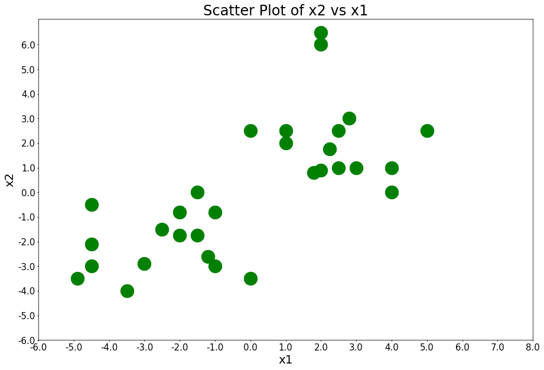

```python
plot_points(figure_title='Scatter Plot of x2 vs x1')
```

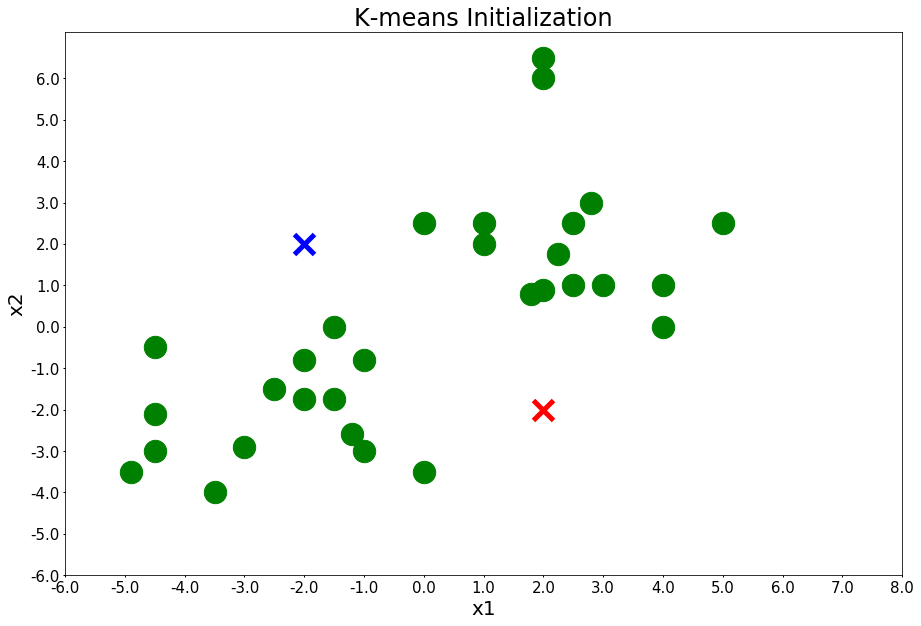

```python
plot_points(centers, figure_title='K-means Initialization')
```

#### Run the iterations 4 times and plot each cluster assignment and plot each center update

Now use the functions that you have implemented and fill out the for loop  
You have to plot two scatter plot for each iteration, one after the cluster assignment and the second after updating the centers  
The last two plots should look like this after running it for 4 iterations after which it converges

[figure not shown]

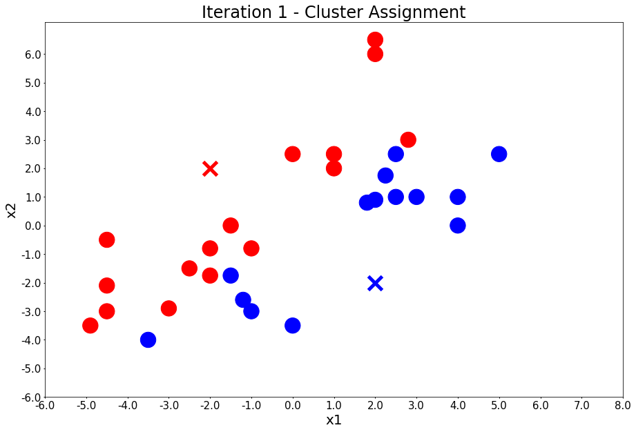

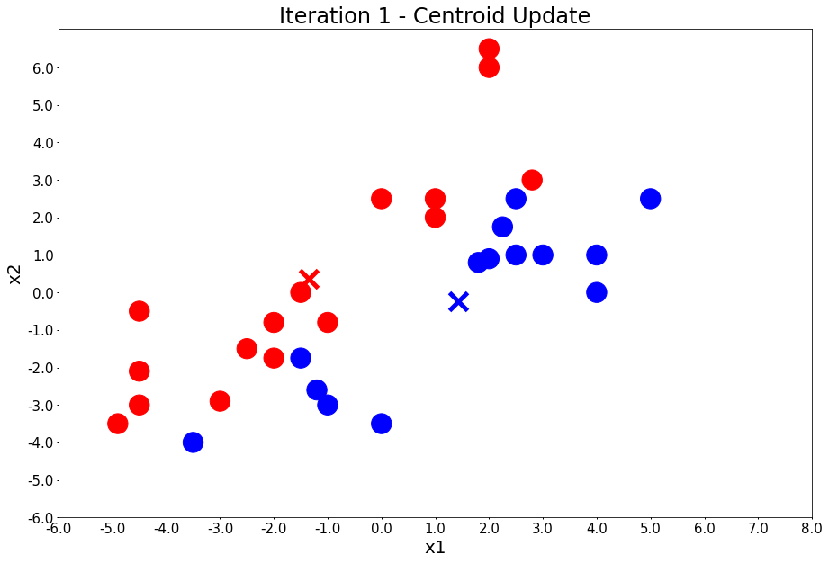

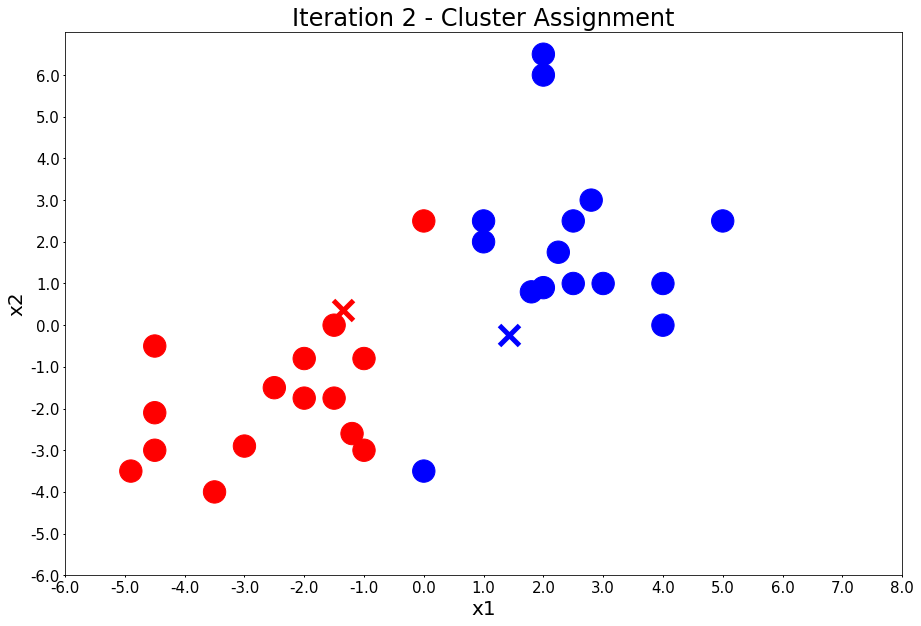

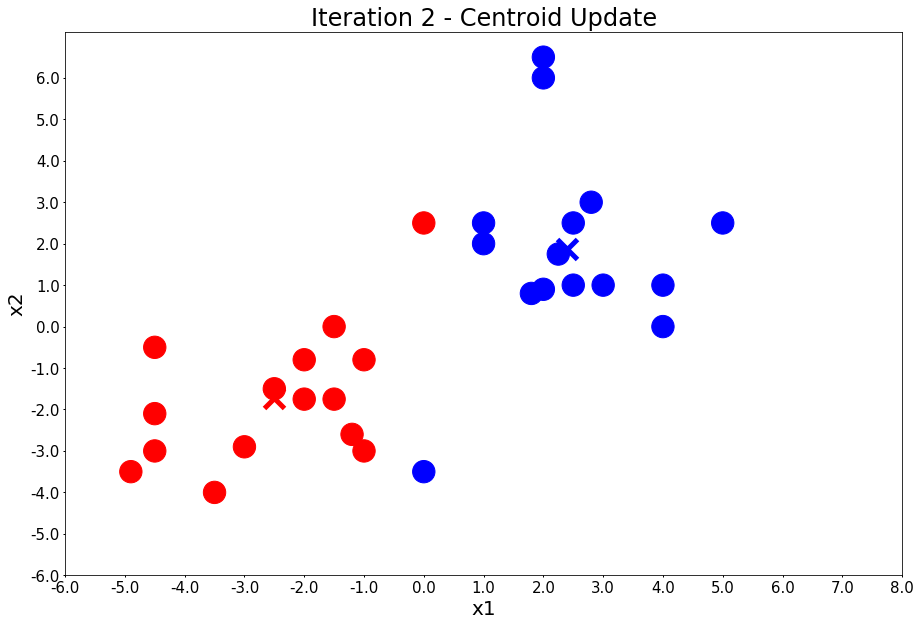

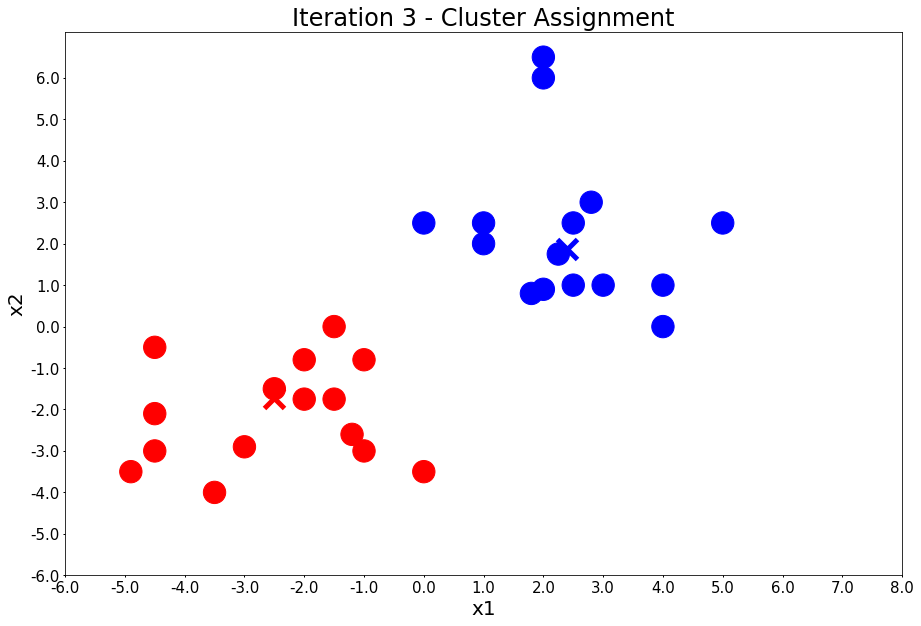

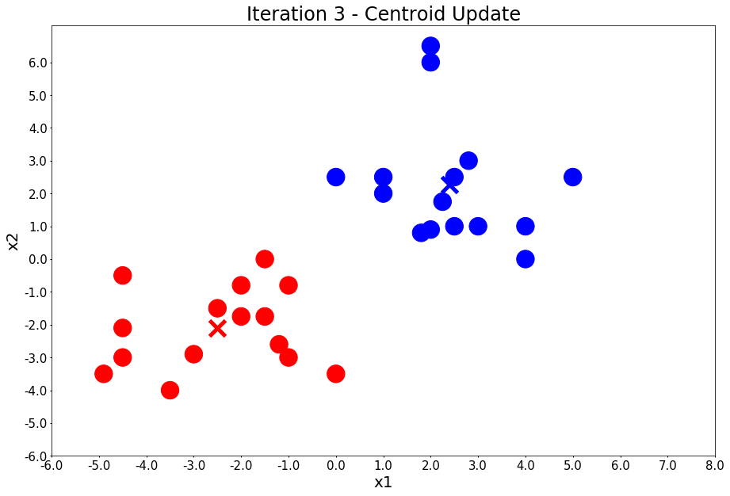

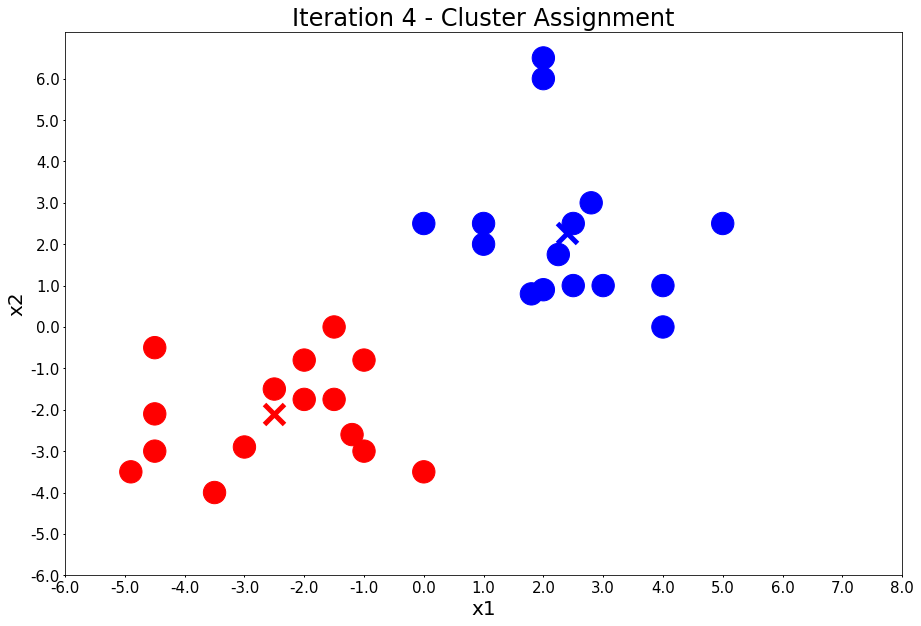

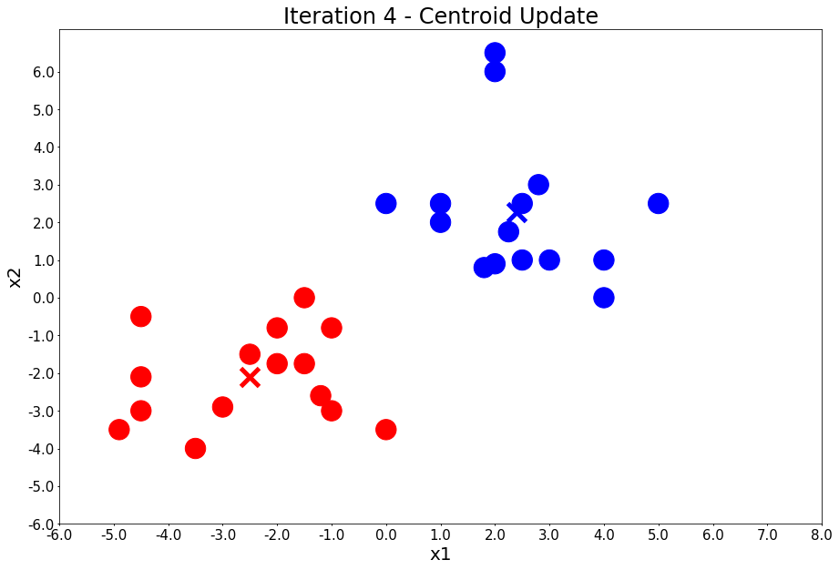

```python
centers = [[2, -2], [-2, 2]]
number_of_iterations = 4
for i in range(0,number_of_iterations):
    # Your code goes here
    colors, class_of_points = assign_members(x1, x2, centers)
    title = 'Iteration {} - Cluster Assignment'.format(i + 1)
    plot_points(centers, colors, figure_title=title)
    centers = update_centers(x1, x2, class_of_points)
    title = 'Iteration {} - Centroid Update'.format(i + 1)
    plot_points(centers, colors, figure_title=title)
```

### 2. *k*-means for Cluster Segmentation and Profile Building

**Step 1)** Read the customer_segemntation csv file into a dataframe and display the first 5 rows

```python
# Your code goes here
customers_df = pd.read_csv('customer_segmentation.csv')
customers_df.head()
```

|  | Customer Id | Age | Edu | Years Employed | Income | Card Debt | Other Debt | Defaulted | Address | DebtIncomeRatio |
| --- | --- | --- | --- | --- | --- | --- | --- | --- | --- | --- |
| 0 | 1 | 41 | 2 | 6 | 19 | 0.124 | 1.073 | 0.0 | NBA001 | 6.3 |
| 1 | 2 | 47 | 1 | 26 | 100 | 4.582 | 8.218 | 0.0 | NBA021 | 12.8 |
| 2 | 3 | 33 | 2 | 10 | 57 | 6.111 | 5.802 | 1.0 | NBA013 | 20.9 |
| 3 | 4 | 29 | 2 | 4 | 19 | 0.681 | 0.516 | 0.0 | NBA009 | 6.3 |
| 4 | 5 | 47 | 1 | 31 | 253 | 9.308 | 8.908 | 0.0 | NBA008 | 7.2 |

**Step 2)** Drop any columns which will not be of any use (if any) and display the first 5 rows

```python
# Your code goes here
df = customers_df.drop('Address', axis=1)
df.head()
```

|  | Customer Id | Age | Edu | Years Employed | Income | Card Debt | Other Debt | Defaulted | DebtIncomeRatio |
| --- | --- | --- | --- | --- | --- | --- | --- | --- | --- |
| 0 | 1 | 41 | 2 | 6 | 19 | 0.124 | 1.073 | 0.0 | 6.3 |
| 1 | 2 | 47 | 1 | 26 | 100 | 4.582 | 8.218 | 0.0 | 12.8 |
| 2 | 3 | 33 | 2 | 10 | 57 | 6.111 | 5.802 | 1.0 | 20.9 |
| 3 | 4 | 29 | 2 | 4 | 19 | 0.681 | 0.516 | 0.0 | 6.3 |
| 4 | 5 | 47 | 1 | 31 | 253 | 9.308 | 8.908 | 0.0 | 7.2 |

**Question:** Explain why you dropped those columns (if any)?

**Answer:** Address was dropped as it is a categorical dataset.

**Step 3)** Check to see if there any NaN entries. Show the count of Nan entries for each column

```python
# Your code goes here
df.isnull().sum(axis = 0)
```

```
Customer Id          0
Age                  0
Edu                  0
Years Employed       0
Income               0
Card Debt            0
Other Debt           0
Defaulted          150
DebtIncomeRatio      0
dtype: int64
```

**Step 4)** You can either drop these Nan entries or fill in the missing values. Show the first 5 rows and the count of Nan entries for each column after you have either dropped or filled the missing values

**Question:** Which method did you use to finish the NaN entries? And why is that method better than the other for K-Means clustering?

**Answer:** Method was to replace all the exact NaN values with zeros. The np.nan_to_num method does this but filling with zeros did the same thing.

**Step 5)** Normalize your data and convert it into a numpy array. Normalization is a statistical method that helps mathematical-based algorithms interpret features with different magnitudes and distributions equally  
Hint: To Normalize checkout SKLearn library for any inbuilt function

```python
# Your code goes here
df.fillna(0)

X = df.values[:,1:] #ignore first indexing columns of dataframe
X = np.nan_to_num(X) #Missing values can also be converted to zeros using this
normX = StandardScaler().fit_transform(X)
```

**Step 6)** Here you will now use SK Learn's library for K-Means. You will use 3 clusters here. Initailize the `n_init` parameter to equal 12

```python
num_clusters = 3

k_means = KMeans(init="k-means++", n_clusters=num_clusters, n_init=12)
k_means.fit(normX)
labels = k_means.labels_
```

**Question:** Here you have been provided with the number of clusters from before. Give two methods where you can find out the optimal number of clusters?  
**Answer:**

1. An Elbow method can be used to plot the variances covered/seen in the dataset with increasing number of clusters. The graph will start to decreasing variance with higher clusters but the curve will start to flatten out. The optimal number of clusters can be seen where this graph initially begins to flatten out.
2. Another method is the sum of squares method which allows us to increase the number of clusters till the sum within all clusters is minimized and the sum between the clusters (i.e how seperated the clusters are) is maximised.

**Step 7)** Add a column to your original dataframe with these labels and name the column `Labels`

```python
df["Labels"] = labels
```

**Step 8)** Visualize your clusters. X is the normalized numpy array. You dont need to implement this, it has already been done for you. The following image shows what the result should more or less look like.

[figure not shown]

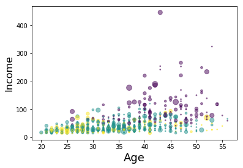

```python
area = np.pi * ( X[:, 1])**2
plt.scatter(X[:, 0], X[:, 3], s=area, c=labels.astype(np.float), alpha=0.5)
plt.xlabel('Age', fontsize=18)
plt.ylabel('Income', fontsize=16)

plt.show()
```

**Step 9)** Here you will do profile building

K-means will partition your customers into three groups since we specified the algorithm to generate 3 clusters. The customers in each cluster are similar to each other in terms of the features included in the dataset.

Now we can create a profile for each group, considering the common characteristics of each cluster.

Compare all 3 clusters and give main characterstics for each profile/cluster.  
For E.g The group which is older in `age` have a higher `income`

Hint: Use groupby

```python
df.groupby('Labels').mean()
```

| Labels | Customer Id | Age | Edu | Years Employed | Income | Card Debt | Other Debt | Defaulted | DebtIncomeRatio |
| --- | --- | --- | --- | --- | --- | --- | --- | --- | --- |
| 0 | 424.408163 | 43.000000 | 1.931973 | 17.197279 | 101.959184 | 4.220673 | 7.954483 | 0.162393 | 13.915646 |
| 1 | 426.122905 | 33.817505 | 1.603352 | 7.625698 | 36.143389 | 0.853128 | 1.816855 | 0.000000 | 7.964991 |
| 2 | 424.451807 | 31.891566 | 1.861446 | 3.963855 | 31.789157 | 1.576675 | 2.843355 | 0.993939 | 13.994578 |

**Question:** Give 2 advantages and 2 disavantages of using K Means Clustering over say a Hierarchal Clustering Method such a Agglomerative Clustering or a Density Based Clustering Method such as DB-Scan?

**Advantages**

1. K-means requires much less computational power and is much faster
2. K-means works very well in producing very tight clusters with maximised distances between clusters

**Disadvantages**

1. Methods such as the DBSCAN dont need the number of clusters to be specified initially but K-means does
2. K-means will not work well for data that has high varying density

## Q2) Hierarchical Clustering

Hierarchical clustering is a type of unsupervised machine learning algorithm used to cluster unlabeled data points. Like K-means clustering, hierarchical clustering also groups together the data points with similar characteristics. There are two types of hierarchical clustering algorithms:

- Agglomerative — Bottom up approach. Start with many small clusters and merge them together to create bigger clusters.
- Divisive — Top down approach. Start with a single cluster than break it up into smaller clusters.

In this question, you will be performing Agglomerative Clustering on a customers shopping habits dataset and then labelling the clusters.

**Question** Load the dataset and look for possible missing values. Handle them appropriately. (If any)

```python
### Code here
dataset = pd.read_csv('customers_shopping.csv')
X = dataset.iloc[:, [3,4]].values
#there were no missing values in the dataset
```

**Dendrogram** is used to visualize the history of groupings and figure out the optimal number of clusters.

**Question:** Draw **two dendograms using two different linkage methods**. *Comment on the cause of differences between the two*.

Pick **one** of the above which you find to be the best. Mention the **number of clusters** and justify your answer.

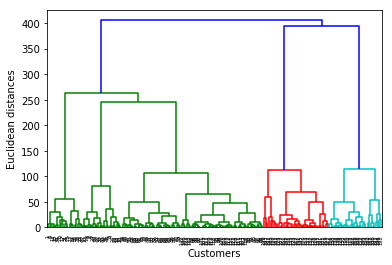

```python
#### Draw dendrogram here
dendrogram = sch.dendrogram(sch.linkage(X, method  = "ward"))
plt.xlabel('Customers')
plt.ylabel('Euclidean distances')
plt.show()
```

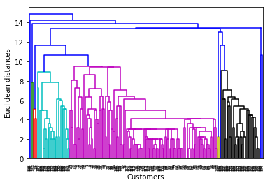

```python
#### Draw dendrogram here
dendrogram = sch.dendrogram(sch.linkage(X, method  = "single"))
plt.xlabel('Customers')
plt.ylabel('Euclidean distances')
plt.show()
```

### Optimal Number of Clusters:

The optimal number of clusters can be seen in the ward linkage method. This number is 5 as indidicated by the dendogram. The dendogram shows linkages between customers resulting in 5 major groups which can be thought of as 5 customer groups.

### Justification:

**Question:** Create an agglomerative cluster using your optimal number of clusters and plot a scatter diagram

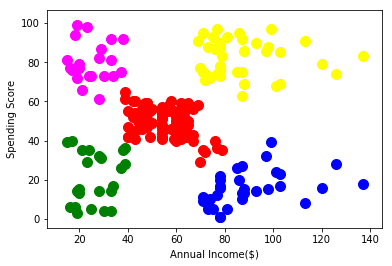

```python
### write your code here
from sklearn.cluster import AgglomerativeClustering

agglo_cluster = AgglomerativeClustering(n_clusters = 5, affinity = 'euclidean', linkage ='ward')

agglo_final=agglo_cluster.fit_predict(X)

plt.scatter(X[agglo_final==0, 0], X[agglo_final==0, 1], s=100, c='blue', label ='Cluster 1')

plt.scatter(X[agglo_final==1, 0], X[agglo_final==1, 1], s=100, c='red', label ='Cluster 2')

plt.scatter(X[agglo_final==2, 0], X[agglo_final==2, 1], s=100, c='yellow', label ='Cluster 3')

plt.scatter(X[agglo_final==3, 0], X[agglo_final==3, 1], s=100, c='magenta', label ='Cluster 4')

plt.scatter(X[agglo_final==4, 0], X[agglo_final==4, 1], s=100, c='green', label ='Cluster 5')
plt.xlabel('Annual Income($)')
plt.ylabel('Spending Score')
plt.show()
```

**Question:** What do each of the clusters represent?

**Answer:** Green cluster represents customers who are sensible spenders. They have a low income but also a low spending score.

Magenta cluster shows customers who are careless because they have a large spending score with a low income. On the other hand, customers who are careful and have a higher income with a low spending score are seen in the blue cluster.

Red cluster shows customers who have a standard or average income along with an average spending score.

Yellow cluster shows comfortable customers who have a high income and a high spending score.